# p8105_hw3_sl4660

Sibei Liu

2019/10/14

```r
library(p8105.datasets)
data("instacart")
library(tidyverse)
library(ggrepel)
```

# Probelm 1

## First

In the instacart dataset, there are 15 variables, 1384617 observations. The key variables are both order_id and product_id. Because those two can locate a piece of data. Take the first row for example, the user with id 112108, made the order with a product whose id was 49302.The product 49302 was his/her first item to add into cart, which had been reordered before. The order sequence number for this user was 4. The day she/he made this order is on Wed. And the detailed time was at 10:00.It was 9 days since her/his last order. The product–Bulgarian Yogurt is from aisle number120,which was yogurt aisle. And the product was from department number16–dairy eggs.

```r
aisle_number=n_distinct(select(instacart,aisle_id))

sub1=instacart %>%
  group_by(aisle) %>%
  summarise(n = n())

sub2=mutate(sub1,aisle_ranking = min_rank(desc(n))) %>%
  arrange(aisle_ranking)

sub2
```

```
## # A tibble: 134 x 3
##    aisle                              n aisle_ranking
##    <chr>                          <int>         <int>
##  1 fresh vegetables              150609             1
##  2 fresh fruits                  150473             2
##  3 packaged vegetables fruits     78493             3
##  4 yogurt                         55240             4
##  5 packaged cheese                41699             5
##  6 water seltzer sparkling water  36617             6
##  7 milk                           32644             7
##  8 chips pretzels                 31269             8
##  9 soy lactosefree                26240             9
## 10 bread                          23635            10
## # ... with 124 more rows
```

There are 134 aisles. The most items are from aisle `fresh vegetables`.

Comment: In the table above, I ranked the aisles according to the ordered items. Then I filter the aisle whose rank is 1.

## Second

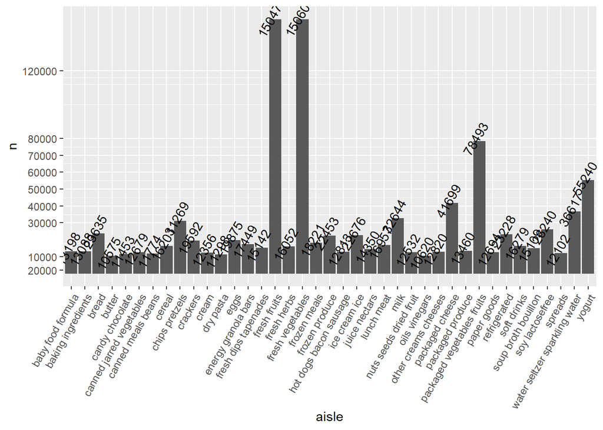

```r
sub2%>%
  filter(n>10000) %>%
  ggplot(aes(x=aisle,y=n,label=n))+geom_bar(stat = "identity")+theme(axis.text.x = element_text(angle = 60, hjust=1))+scale_y_continuous(breaks =                                                      c(10000,2000,30000,40000,50000,60000,70000,80000,120000),
    labels = c("10000","20000","30000","40000","50000","60000","70000","80000","120000"))+
   geom_text(
    aes(label = n,angle=60),
    position = position_dodge(0.9),
    vjust = 0
  )
```

Comment:By using the above table to make plot, the fresh fruits and fresh vegitables had the greatest values. Packaged vegitables followed them. The rest of products such as baby food formula, candy chocolate and so on had lower but consistent values.

## Third

```r
sub3=instacart %>%
  group_by(product_id,aisle_id) %>%
  summarize(n=n())

sub4=instacart %>%
  group_by(product_name,aisle) %>%
  summarize(n=n()) %>%
group_by(aisle) %>%
  mutate(item_ranking_in_each_group = (min_rank(desc(n)))) %>%
  arrange(aisle,item_ranking_in_each_group)

sub4_4=sub4 %>%
  filter(aisle %in% c("baking ingredients", "dog food care","packaged vegetables fruits")&item_ranking_in_each_group<4 )
knitr::kable(sub4_4)
```

| product_name | aisle | n | item_ranking_in_each_group |
| --- | --- | --- | --- |
| Light Brown Sugar | baking ingredients | 499 | 1 |
| Pure Baking Soda | baking ingredients | 387 | 2 |
| Cane Sugar | baking ingredients | 336 | 3 |
| Snack Sticks Chicken & Rice Recipe Dog Treats | dog food care | 30 | 1 |
| Organix Chicken & Brown Rice Recipe | dog food care | 28 | 2 |
| Small Dog Biscuits | dog food care | 26 | 3 |
| Organic Baby Spinach | packaged vegetables fruits | 9784 | 1 |
| Organic Raspberries | packaged vegetables fruits | 5546 | 2 |
| Organic Blueberries | packaged vegetables fruits | 4966 | 3 |

Comment: In baking and ingredients aisle, the light brown sugar had the highest amount. Then pure baking soda and cane sugar followed, which had amount od 387,336 respectively. In dog food care aisle, the “Snack Sticks Chicken & Rice Recipe Dog Treats” had the highest amount, 30. Then “Organix Chicken & Brown Rice Recipe” and “Small Dog Biscuits” followed, which had amount od 28,26 respectively. In packaged vegetables fruits aisle, the “Organic Baby Spinach” had the highest amount–9784. Then “Organic Raspberries” and “Organic Blueberries” followed, which had amount od 5546,4966 respectively.

## Fourth

```r
sub5=instacart %>%
  select(product_name,order_dow,order_hour_of_day) %>%
  filter(product_name %in% c("Pink Lady Apples","Coffee Ice Cream")) %>%
  mutate(
    order_dow=recode(order_dow, `0`="Sun",`1`="Mon",`2`="Tue",`3`="Wed",`4`="Thur",`5`="Fri",`6`="Sat"),
    order_dow=forcats::fct_relevel(order_dow,c("Mon","Tue","Wed","Thur","Fri","Sat","Sun"))
  )  %>%
  group_by(product_name,order_dow) %>%
  summarise(mean_eachday_week=mean(order_hour_of_day)) %>%
  pivot_wider(
   names_from= product_name,
    values_from= mean_eachday_week
  )
knitr::kable(sub5)
```

| order_dow | Coffee Ice Cream | Pink Lady Apples |
| --- | --- | --- |
| Mon | 14.31579 | 11.36000 |
| Tue | 15.38095 | 11.70213 |
| Wed | 15.31818 | 14.25000 |
| Thur | 15.21739 | 11.55172 |
| Fri | 12.26316 | 12.78431 |
| Sat | 13.83333 | 11.93750 |
| Sun | 13.77419 | 13.44118 |

Comment: From Monday to Sunday, the mean hour of ordering coffee and ice cream is 14.3, 15.4, 15.3,15.2, 12.2, 13.8, 13.7 respectively. The time was focused on the beginning of afternoon. From Monday to Sunday, the mean hour of ordering pink lady apples is 11.4, 11.7, 14.3, 11.6, 12.8, 11.9, 13.4 respectively. The time was focused around the noon.

# Problem2

```r
library(p8105.datasets)
data("brfss_smart2010")
```

## Basic data cleaning

```r
sub6=brfss_smart2010 %>%
  janitor::clean_names() %>%
  filter(topic=="Overall Health") %>%
 filter(response%in% c("Excellent","Very good","Good","Fair","Poor")) %>%
  mutate(response = forcats::fct_relevel(response, c("Poor", "Fair", "Good","Very good","Excellent")))
```

## First

```r
sub7=sub6 %>%
  filter(year==2002) %>%
  group_by(locationabbr,locationdesc) %>%
  summarise(n=n())
sub8=sub7 %>%
  group_by(locationabbr) %>%
  summarise(n=n()) %>%
 filter(n>6)
  sub8
```

```
## # A tibble: 6 x 2
##   locationabbr     n
##   <chr>        <int>
## 1 CT               7
## 2 FL               7
## 3 MA               8
## 4 NC               7
## 5 NJ               8
## 6 PA              10
```

```r
location1=c(pull(sub8,locationabbr))
```

```r
sub9=sub6 %>%
  filter(year==2010) %>%
  group_by(locationabbr,locationdesc) %>%
  summarise(n=n())
sub10=sub9 %>%
  group_by(locationabbr) %>%
  summarise(n=n()) %>%
 filter(n>6)
 sub10
```

```
## # A tibble: 14 x 2
##    locationabbr     n
##    <chr>        <int>
##  1 CA              12
##  2 CO               7
##  3 FL              41
##  4 MA               9
##  5 MD              12
##  6 NC              12
##  7 NE              10
##  8 NJ              19
##  9 NY               9
## 10 OH               8
## 11 PA               7
## 12 SC               7
## 13 TX              16
## 14 WA              10
```

```r
location2=c(pull(sub10,locationabbr))
```

In 2002, CT, FL, MA, NC, NJ, PA have 7 and above locations. In 2010, CA, CO, FL, MA, MD, NC, NE, NJ, NY, OH, PA, SC, TX, WA have 7 and above locations.

Comment: In 2002, CT, FL, MA, NC, NJ, PA have respectively 7, 7, 8, 7, 8, 10 observations. In 2010, CA, CO, FL, MA, MD, NC, NE, NJ, NY, OH, PA, SC, TX, WA have respectively 12, 7, 41, 9, 12, 12, 10, 19, 9, 8, 7, 7, 16, 10 observations.

## Second

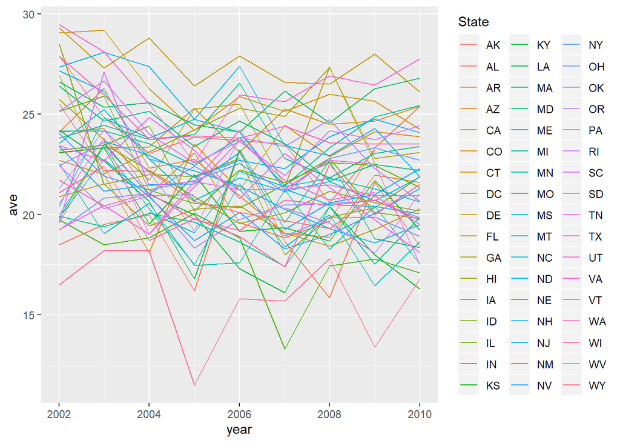

```r
sub11=sub6 %>%
  filter(response=="Excellent")%>%
  group_by(locationabbr,year) %>%
  mutate(ave=mean(data_value)) %>%
 select(year,locationabbr,ave)

p1=ggplot(sub11,aes(x=year,y=ave, color = locationabbr))+geom_line()+ scale_color_hue(name = "State")
p1
```

Comment: The WV state have the lowest value of spaghetti during 2002-2010. And the values of spaghetti in each state were not stable during those years.

## Third

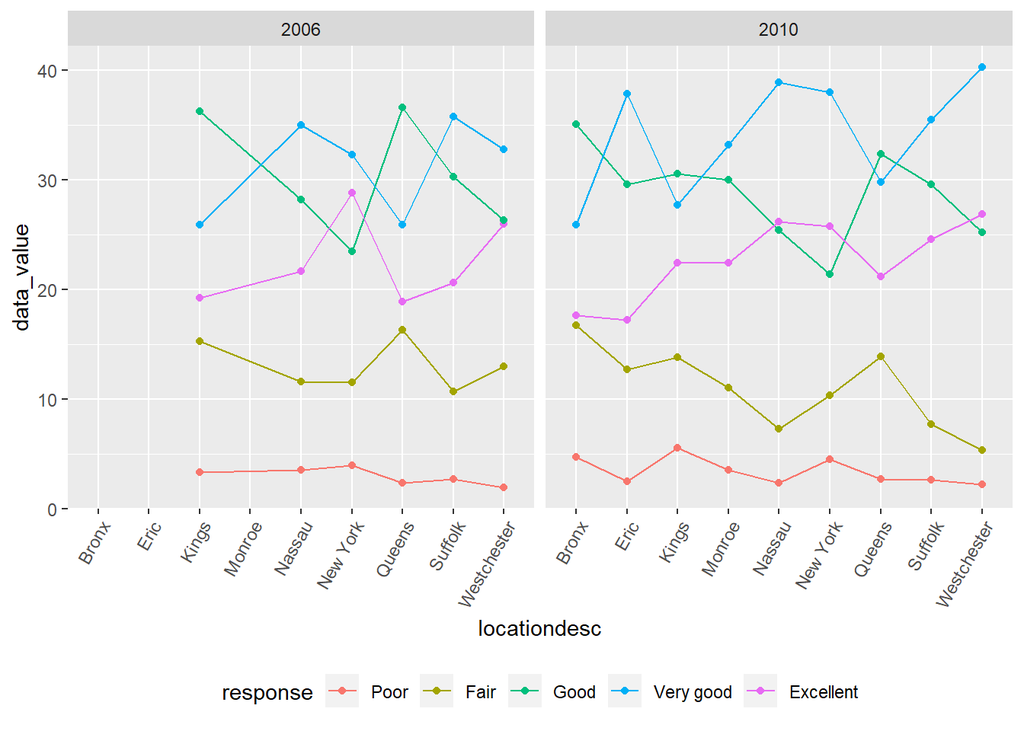

```r
sub12=sub6 %>%
  filter(locationabbr=="NY"&year %in% c("2006","2010")  ) %>%
 select(data_value,response,locationdesc,year)
sub12 %>%
  mutate(
    locationdesc=recode(locationdesc,"NY - Bronx County"="Bronx","NY - Erie County"="Eric", "NY - Kings County"="Kings","NY - Monroe County"="Monroe",  "NY - New York County"="New York","NY - Nassau County"="Nassau","NY - Queens County"="Queens","NY - Suffolk County"="Suffolk","NY - Westchester County"="Westchester"))%>%
  ggplot(aes(x=locationdesc,y=data_value,color=response,group=response))+
  geom_point()+geom_line()+theme(axis.text.x = element_text(angle = 60, hjust=1),legend.position = "bottom")+
  facet_grid(.~year)
```

# Problem3

## First Tidy data

```r
accel_data=read_csv("./data/accel_data.csv") %>%
  janitor::clean_names() %>%
mutate(day_class=case_when(
    day %in% c("Monday","Tuesday","Wednesday","Thursday","Friday")~ "weekday",
    day %in% c("Saturday","Sunday")~ "weekend",
    TRUE     ~ ""
  ))  %>%
  mutate(
    week=as.factor(week),
    day_id=as.integer(day_id),
    day=forcats::fct_relevel(day,c("Monday","Tuesday","Wednesday","Thursday","Friday","Saturday","Sunday"))
  ) %>%
  pivot_longer(
  activity_1:activity_1440,
  names_to="minute",
  names_prefix = "activity_",
  values_to="activity_count"
  ) %>%
  mutate(minute= as.numeric(minute)) %>%
  arrange(day)

accel_data
```

```
## # A tibble: 50,400 x 6
##    week  day_id day    day_class minute activity_count
##    <fct>  <int> <fct>  <chr>      <dbl>          <dbl>
##  1 1          2 Monday weekday        1              1
##  2 1          2 Monday weekday        2              1
##  3 1          2 Monday weekday        3              1
##  4 1          2 Monday weekday        4              1
##  5 1          2 Monday weekday        5              1
##  6 1          2 Monday weekday        6              1
##  7 1          2 Monday weekday        7              1
##  8 1          2 Monday weekday        8              1
##  9 1          2 Monday weekday        9              1
## 10 1          2 Monday weekday       10              1
## # ... with 50,390 more rows
```

Describtion: There are 35 days to observe in original dataset, indicating the activity change in each day in 5 weeks. I merged the activities into one variable named “miniute” and input the values of each activity into activty_count.There are six variables after merging. They are week, day_id, day_class, day, minute and activity_count.

## Second

```r
ac1=accel_data %>%
  group_by(week,day) %>%
  summarise(total=sum(activity_count))
ac2=pivot_wider(
  ac1,
    names_from = "day",
  values_from = "total"
  )
ac2
```

```
## # A tibble: 5 x 8
## # Groups:   week [5]
##   week   Monday Tuesday Wednesday Thursday  Friday Saturday Sunday
##   <fct>   <dbl>   <dbl>     <dbl>    <dbl>   <dbl>    <dbl>  <dbl>
## 1 1      78828. 307094.   340115.  355924. 480543.   376254 631105
## 2 2     295431  423245    440962   474048  568839    607175 422018
## 3 3     685910  381507    468869   371230  467420    382928 467052
## 4 4     409450  319568    434460   340291  154049      1440 260617
## 5 5     389080  367824    445366   549658  620860      1440 138421
```

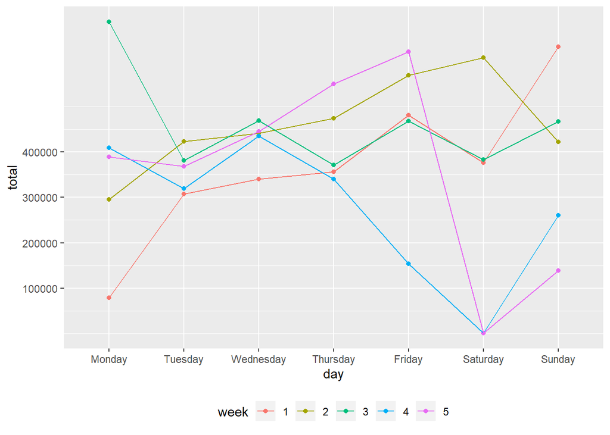

```r
  ggplot(ac1,aes(x=day,y=total,color=week))+geom_point()+geom_line(aes(group=week))+ylim(1,400000)+
   scale_y_continuous(
    breaks = c(100000,200000,300000,400000),
    labels = c("100000","200000","300000","400000")
    )+theme(legend.position = "bottom")
```

Comment:I made the above graph to try to find any trend. But unfortunately Within week one, the general trend is upward from Monday to Sunday. In week two, the general trend is upward. But there is a slight drop on Sunday. In week three, a drop is observed from Monday to Tuseday, then a fluctuation follows. In week four, the general trend is downward. In week five, from Monday to Friday, there is an increase, But I failed to find any solidc general trend between weeks. Because each of them have different trends.

## Third

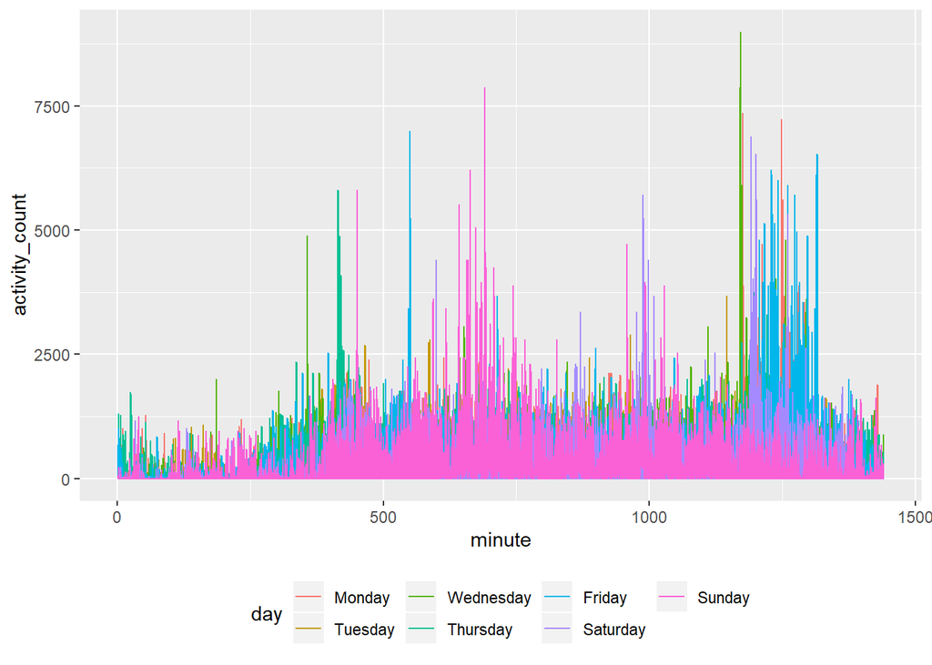

```r
 ggplot(accel_data,aes(x=minute,y=activity_count,color=day))+geom_line(aes(group=day))+theme(legend.position = "bottom")
```

In this graph, I can find the peak of Sunday is different from the peak of other days. The peak of Sunday is around the 600th minute of the day. While peaks of other days(except Sunday) gathers in around 1250th minute. And from 0 minute to 400 minute, there is less activitiy amount because the beginning of the day is sleep time.